[figure not shown]

# 1er Parcial (16/12/2020) - Funciones, Límites y Derivadas

# Criterios de evaluación.

1.- Prolijidad.

2.- Pertinencia conceptual, síntesis y precisión.

3.- Desarrollo adecuado.

4.- Exactitud en los resultado.

### 5.- Para aquellos que no puedan realizar en Jupyter Notebook, seleccionen el medio a disposición, y apliquen los criterios mencionados antecedentemente.

"Los incito a tratarnos, en la medida de lo posible, como lo que van a llegar a ser. Se que pueden, y estamos para ayudarlos a lograr ese objetivo".

Keep learninig and practicing...

## Link de notación matemática para Markdown

https://www.overleaf.com/learn/latex/Integrals,_sums_and_limits

## Learn How to Write Markdown & LaTeX in The Jupyter Notebook

https://towardsdatascience.com/write-markdown-latex-in-the-jupyter-notebook-10985edb91fd

#### Markdown es el formato que nos permite escribir en el documento, en éste caso Jupyter Notebook.

#### Utiliza un leguaje de texto llamado LaTeX.

#### EL enlace conduce a un tutorial básico.

#### Verán que es muy útil dado que nos permite escribir fórmulas y símbolos matemáticos.

# Funciones

1.- Dominio, rango y regla, a que hacen referencia. Exprese en una definición. Aplique la misma en simbología matemática.

2.- Evalue el dominio. Expresar en notación simbólica

a) $ f(x) = \frac{1}{x-10} $

b) $ f(t) = \sqrt{16 - t^2} $

c) $ f(x) = \frac{x - 3}{2} $ $ \hspace{2cm} $ $ g(x) = \sqrt{x} $  
Evalue $ (f + g)(x) $

2) a) { x | x ≠ 10 }

b) { t | −4 ≤ t ≤ 4 }

c) x ≥0 [0,∞)

3.- Dado el conjunto A y B, indique cuales corresponden a una función y cuales no:

a) $ A:\left\{0,1,2,3,4,5,6,7,8,9\right\} \hspace{1cm} - \hspace{1cm} B:\left\{0,1,2,3,4,5,6,7,8,9\right\} $

b) $ A:\left\{1,2,2,4,4,4,6,6,6,6\right\} \hspace{1cm} - \hspace{1cm} B:\left\{1,1,2,1,2,4,1,2,4,6\right\} $

c) $ A:\left\{0,1,2,3,4,5,6,7,8,9\right\} \hspace{1cm} - \hspace{1cm} B:\left\{1,1,1,1,1,1,1,1,1,1\right\} $

d) $ A:\left\{0,1,2,3,4,5,6,7,8,9\right\} \hspace{1cm} - \hspace{1cm} B:\left\{0,1,4,9,16,25,32,49,64,81\right\} $

e) $ A:\left\{1,1,1,1,1,1,1,1,1,1\right\} \hspace{1cm} - \hspace{1cm} B:\left\{0,1,2,3,4,5,6,7,8,9\right\} $

3- Una relación es una correspondencia de elementos entre dos conjuntos. Una función es una relación en donde a cada  
elemento de un conjuto (A) le corresponde uno y sólo un elemento de otro conjunto (B). Todas las funciones tienen un dominio y un contradominio.

```
a)si tomamos al conjunto A como el conjunto de partida y B como el cojunto de llegada,
```

podemos decir que **si** corresponde a una funcion.

```
b)si tomamos al conjunto A como el conjunto de partida y B como el cojunto de llegada,
```

podemos decir que **no** corresponde a una funcion.

```
c)si tomamos al conjunto A como el conjunto de partida y B como el cojunto de llegada,
```

podemos decir que **si** corresponde a una funcion.

```
d)si tomamos al conjunto A como el conjunto de partida y B como el cojunto de llegada,
```

podemos decir que **si** corresponde a una funcion.

```
e)si tomamos al conjunto A como el conjunto de partida y B como el cojunto de llegada,
```

podemos decir que **no** corresponde a una funcion.

4.- Dadas las siguientes expresiones matemáticas, indique cuales corresponden a funciones y cuales no:

a) $ f(x) = 2\pi \frac{3x^3 + 10x}{x -2} $

b) $ 2x + 3y^2 - \sqrt{x + 10} = 21 $

c) $ \begin{vmatrix} x \end{vmatrix} = \left\{ \begin{array} \\ x & \mbox{if } x \geq 0 \\ -x & \mbox{if } x < 0 \end{array} \right. $

d) $ G(t) = \left\{ \begin{array} \\ 1 & \mbox{if } t \leq 0 \\ t + 1 & \mbox{if } 0 < t < 2 \\ t^2 -1 & \mbox{if } t > 2 \end{array} \right. $

4-  
a)**Si** es una función.

b)**No** es una función.

c) **Si** es una función.

d) **Si** es una función.

5.- Se fabrica un depósito abierto de latón con base cuadrada y capacidad para 4000 litros, ¿qué dimensiones debe tener para optimizar el area de almacenamiento lo mejor posible? No se tiene problema en altura. Escribir las expresiones matematicas. Son funciones o ecuaciones?

5- La funciòn qie tenemos que minimizar es el area del deposito $A=x^2+4xy^b$ con la condición de que el volumen $V=x^2y$ se de 4000 litros.

$x^2y=4000$ $\Rightarrow$ ${y} = \frac{4000}{x^2}$ , por tanto, $A=x^2+4x\frac{4000}{x^2} $

$A=x^2+\frac{16000}{x} $ (función a minimizar)

$A=x^2+1600x^{-1}$ ; $A´=2-1.16000x^{-2}$ $=2x -\frac{16000}{x^2}= \frac{2x^3-16000}{x^2} $

si hacemos $A´=0$ , $2x^3-16000=0$ $\Rightarrow$ $x^3=8000$ $\Rightarrow$ $x=20$

Segunda derivada $A´´=\frac{6x^2 x^2-2x(2x^2-16000)}{x^4} $

Para $X=20$ ; $A´´(20)= \frac{2.20^3+32000}{20^3} > 0$ $\Rightarrow$ Para $x=20$ La superficie es mínima

Si $x=20$ , $y= \frac{4000}{20^2}=10$

# Límites

1.- Encontrar la relación $ \hspace{1cm} $ $ \delta(\epsilon) $ $\hspace{1cm}$ que nos permite probar que $ \hspace{1cm} $ $ lim _{x \to 1} \frac{2x + 1}{x - 3} = -\frac{3}{2} $

Dar la definición de límite.

1-En análisis real y complejo, el concepto de **límite** es la clave de toque que formaliza la noción intuitiva de aproximación hacia un punto concreto de una sucesión o una función, a medida que los parámetros de esa sucesión o función se acercan a un determinado valor. En el análisis los conceptos de series convergentes, derivada e integral definida se fundamentan mediante el concepto de límite.

En cálculo (especialmente en análisis real y matemático) este concepto se utiliza para definir los conceptos fundamentales de convergencia, continuidad, derivación, integración, entre otros. Si bien, el concepto de límite parece intuitivamente relacionado con el concepto de distancia, en un espacio euclídeo, es la clase de conjuntos abiertos inducidos por dicha métrica, lo que permite definir rigurosamente la noción de límite.

2.- Defina continuidad de una función. Exprese en simbolos.

2- En matemáticas, una función continua es aquella para la cual, intuitivamente, para puntos cercanos del dominio se producen pequeñas variaciones en los valores de la función; aunque en rigor, en un espacio métrico como en variable real, significa que pequeñas variaciones de la función implican que deben estar cercanos los puntos.

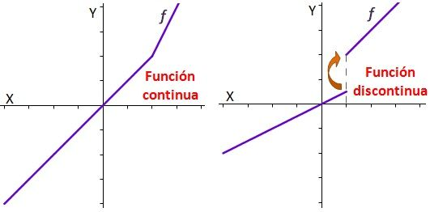

La continuidad de una función se estudia en diferentes sectores de la función:

```
*Continuidad en un punto
*Continuidad lateral
*Continuidad en un intervalo
```

3.- Pruebe que el límte de $ \hspace{1cm} lim_{x \to 4} (3x - 7) \hspace{1cm} $ es 5

3- $ \hspace{1cm} lim_{x \to 4} (3x - 7) \hspace{1cm} $ es **5**

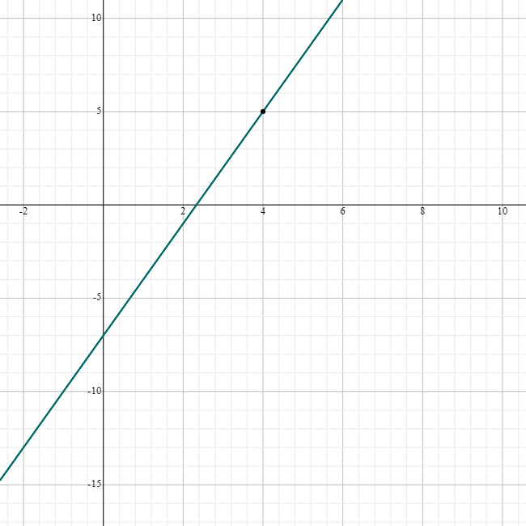

4- $ \hspace{1cm} lim_{x \to -2} \frac{x^2 + 7x + 10}{x +2} \hspace{1cm} $ es **3**

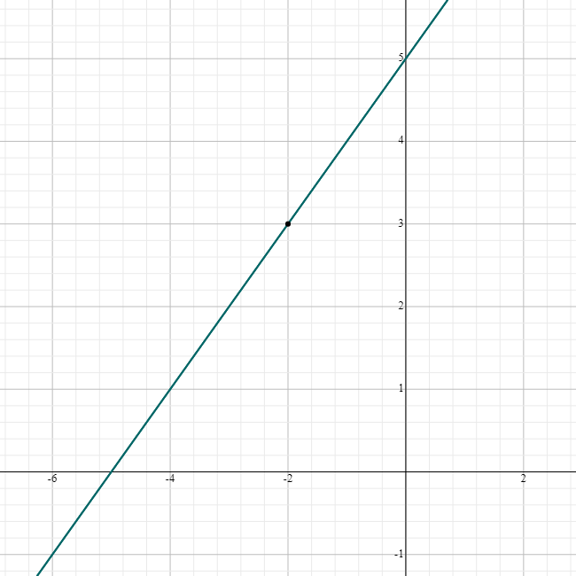

5.- De dos (2) ejemplos de discontinuidad.

5- Una discontinuidad es evitable en un punto ${x = a}$ si existe ${\displaystyle\lim_{x \to a}f(x)}$ y este es finito.

Ejemplo 1: La funcion no esta definida en x=a

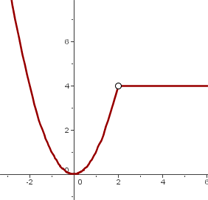

Ejemplo 2: La imagen no coincide con el limite

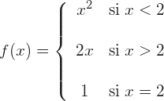

La funcion si esta definida $x=2$ esto es $f (2) = 1$

la funcion presenta una discontinuidad evitable en $x=2$ porque la imagen no coincide con el limite

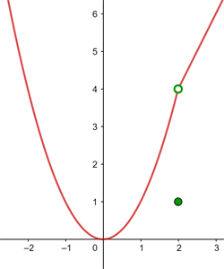

# Derivadas

1.- Indicar si c/u de las siguientes proposiciones es verdadera o falsa. Justificar toda respuesta, si es V demostrarla y si es Falsa dar un contraejemplo adecuado.

a) Toda función continua en un punto es derivable en ese punto.

b) Toda función derivable en un punto es continua en ese punto.

1- La opción **a** es falsa y la opción **b** es verdadera por que: Toda función f derivable en un punto, con derivada finita, es continua en ese punto. El recíproco no es cierto, existen funciones continuas en un punto y no son derivables en él.

2.- Expresar el concepto de derivada de una función. Escribir la definición simbólicamente.

2- El concepto de derivada de una función matemática se halla íntimamente relacionado con la noción de límite. Así, la derivada se entiende como la variación que experimenta la función de forma instantánea, es decir, entre cada dos puntos de su dominio suficientemente próximos entre sí. La idea de instantaneidad que transmite la derivada posee múltiples aplicaciones en la descripción de los fenómenos científicos, tanto naturales como sociales. Derivada de una función en un punto

Este límite también puede expresarse de las dos formas alternativas siguientes:

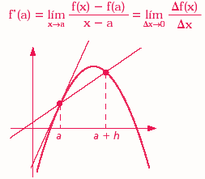

Apoyo gráfico para la definición de derivada en un punto.

3.- Un heladero ha comprobado que, a un precio de 50 pesos la unidad, vende una media de 200 helados diarios. Por cada peso que aumenta el precio, vende dos helados menos al día. Si el coste por unidad es de 40 pesos, ¿a qué precio de venta es máximo el beneficio diario que obtiene el heladero? ¿Cual será ese beneficio? Resolver y dejar las fórmulas utilizadas.

3-Llamamos x al número de céntimos en los que aumenta el precio. Así, cada helado costará 50 + x céntimos; y venderá 200 - 2x helados diarios. Por tanto, por la venta de los helados obtendrá unos ingresos:

$I (x) = (50 + x) (200 - 2x)$

Pero tiene unos gastos de: $G (x) = (200 - 2x) · 40$

Luego, el beneficio será de:

$B (x) = I (x) - G (x) = (50 + x) (200 - 2x) - (200 - 2x) · 40 = (200 - 2x) (50 + x - 40) =$

$= (200 - 2x) (x + 10)$

$=-2x2$ + 180x + 2000

Hallamos x para que el beneficio sea máximo:

$B'(x) = -4x + 180$

$B'(x) = 0 → -4x + 180 = 0 → x = 45$

$B''(x) = -4; B''(45) < 0 →$ en $x = 45$ hay un máximo

4.- Hay dos (2) tangentes a la curva $ \hspace{1cm} y = 4x - x^2 \hspace{1cm} $ que pasan por el punto (2,5). Encuentre las ecuaciones de ambas. Sugerencia: Sea $(x_ 0, y_ 0) $ el punto de tangencia, encuentre las dos condiciones que debe satisfacer dicho punto.

$\frac{dy}{dx}=$ $4-2x$

5.- Resolver las derivadas:

a) $ y= \frac{2}{x} - \frac{1}{x^2} $

b) $ y = (x^2 + 17)(x^3 - 3x + 1) $

c) $ f(x) = \left\{ \begin{array} \\ 2x^2 + 1 & \mbox{if } x \leq 1 \\ x + 2 & \mbox{if } x > 1 \end{array} \right. $

d) $ y = x^2 sen(x)$

5- a- $- \frac{2}{x^2}+ \frac{2}{x^3}$

b- $5x^4+ 42x^2+2x-51 $

d- $x^2 cos (x) + 2x. sen (x)$